# AFDMD-111 Estadística

Cálculo de probabilidad de VAs

# Variables aleatorias discretas

Como se ha mencionado en clases pasadas existen tres tipos de variables aleatorias; discretas, continuas y mixtas. Para nuestro curso, estaremos interesados en las variables aleatorias discretas y continuas. Recordemos que para las variables aleatorias discretas contamos con dos funciones que las describen totalmente; la función de distribución y la función de densidad. La función de distribución está dada por:
$$F_X(x) = P(X \le x)$$
para cualquier valor $x \in \mathbb{R}$. La función de masa de probabilidad es la otra función que se define de la siguiente manera:
$$p_X(k) = P(X=k)$$
Por lo tanto, cuando se nos dá una variable aleatoria discreta ésta está definida por una fórmula que representa $p_X(k)$ o $F_X(x)$. La variable aleatoria binomial, por ejemplo está dada por:
$$p_X(k) = \binom{n}{k}p^k(1-p)^{n-k}\; \;\;\; k=0,1,2, \ldots n$$
En R, los comandos `dbinom, pbinom, rbinom` y `qbinom` generan las pmfs, distribuciones y números aleatorios relacionados a la variable aleatoria discreta Binomial. Por ejemplo, el siguiente código genera $100$ números aleatorios de una distriubción binomial con parámetros $n=16$, $p=0.1$ y posteriormente se grafican.

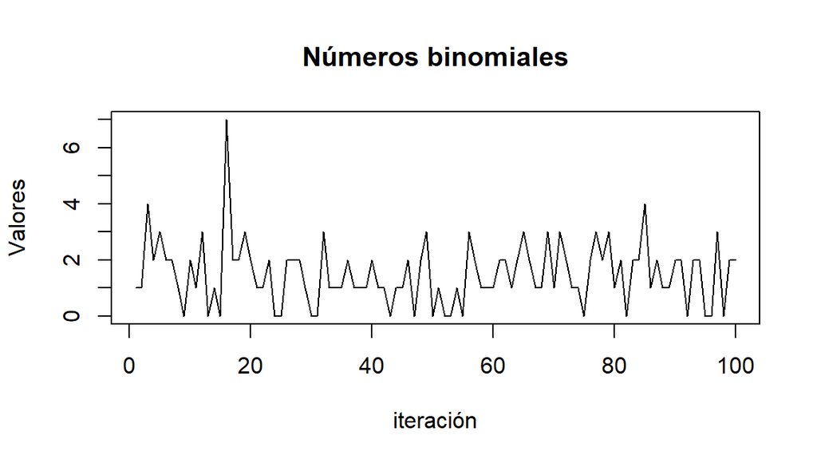

```r
vars <-rbinom(100, size=16, prob=0.1)
plot(vars, type="l", main="Números binomiales", xlab="iteración", ylab="Valores")
```

## Actividad

Investigue la generación de *pmfs* y *cdfs* discretas en R o python y posteriormente calcule las siguientes probabilidades usando únicamente código:

1. Sea $X$ una variable aleatoria que tiene distribución binomial con $p=0.4$ y $n=20$. Calcular:
1. $P(X\le 6)$

```r
p <- 0.4
n <- 20
x <- 0:6
prob_1 <- sum(dbinom(x, size = n, prob = p))
prob_1
```

```
## [1] 0.2500107
```

2. $P(X\ge 12)$

```r
p <- 0.4
n <- 20
x <- 12:20
prob_2<- sum(dbinom(x, size = n, prob = p))
prob_2
```

```
## [1] 0.05652637
```

3. $P(X=8)$

```r
p <- 0.4
n <- 20
prob_3<-dbinom(8, size = n, prob = p)
prob_3
```

```
## [1] 0.1797058
```

2. El comando `sample`, me permite generar números aleatorios con una *pmf* que define el usuario. Generar 100 números aleatorios con las siguientes pmfs:
1. $p_X(k) = {5\choose k}\left(\frac{1}{5}\right)^k \left(\frac{4}{5}\right)^{5-k}, \;\; k=0,1,2,3,4,5.$

```r
pmf <- function(k) choose(5, k) * (1/5)^k * (4/5)^(5 - k)
probs <- sapply(0:5, pmf)
random_numbers <- sample(0:5, 100, replace = TRUE, prob = probs)
print(random_numbers)
```

```
##   [1] 2 0 1 0 2 2 1 1 2 2 1 1 0 1 1 1 2 0 0 0 0 2 1 2 1 1 2 0 0 1 0 1 2 1 1 1 2
##  [38] 1 2 1 2 1 1 2 1 2 1 2 0 0 2 2 1 1 1 0 0 2 2 1 1 1 1 2 0 0 1 1 1 1 2 2 1 1
##  [75] 1 1 1 1 1 0 0 1 0 0 3 1 2 2 1 0 1 2 1 2 0 1 1 0 0 0
```

2. $p_X(k) = \frac{k^2}{2870}, \;\; k=0,1,2,3,\ldots, 19, 20$

```r
pmf <- function(k) k^2 / 2870
probs <- sapply(0:20, pmf)
random_numbers <- sample(0:20, 100, replace = TRUE, prob = probs)
print(random_numbers)
```

```
##   [1] 19 13 16 20 15 16 17 20 15 17 20 18  8 19  8 18 14 19 13 17 15 18 17 16 18
##  [26] 20 11 18 14 18 12 19 13 15 20 14 14  8  5 12 20 16 19  6 17  7 17 10 17  9
##  [51] 17 19 16 14 18 18 17  3 20 19 18 18  6 15 20 14 20 20 20 14 17 13 18 12 13
##  [76] 19 15 19  9 15 11 20 18 20 16 18 15 19 19 14 13 16 17 15 18 18 20 11 15 19
```

3. $p_X(k) = \log_{10}\left(\frac{k+1}{k}\right)\; \; k=1,2,3, \ldots 9$

```r
pmf <- function(k) log10((k + 1) / k)
probs <- sapply(1:9, pmf)
probs <- probs / sum(probs)#normalizar las probabilidades
random_numbers <- sample(1:9, 100, replace = TRUE, prob = probs)
print(random_numbers)
```

```
##   [1] 2 7 5 2 4 4 1 3 1 7 1 4 1 1 5 1 4 6 6 7 6 1 5 1 1 3 2 1 1 5 7 6 3 2 3 4 4
##  [38] 5 6 6 7 1 1 1 1 2 8 8 4 5 2 1 1 1 6 3 2 9 6 4 3 2 1 8 8 7 2 6 4 4 1 3 5 3
##  [75] 7 1 6 6 1 1 2 2 2 2 1 4 3 1 1 1 8 2 6 3 4 1 4 7 4 4
```

3. La variable aleatoria binomial depende de los parámetros $n$ y $p$. Grafique las pmfs y cdfs para (Nota para graficar por parejas puede usar el comando `par(mfrow=(filas, columnas))`) y responda las preguntas:
1. $n=10$ y $p=1/2$

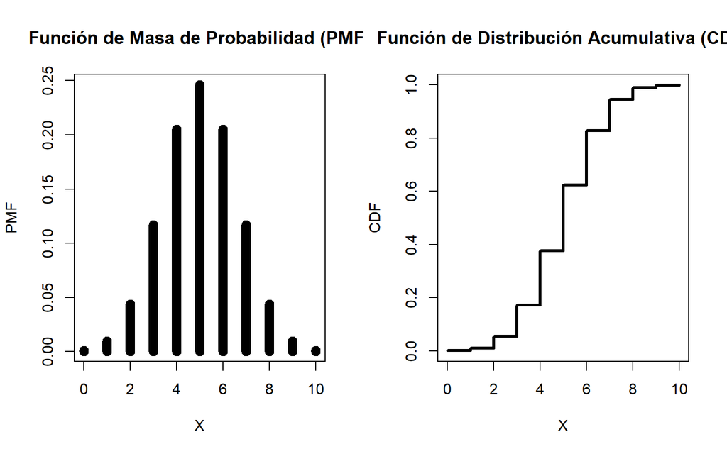

```r
library(ggplot2)
n <- 10
p <- 0.5
x <- 0:n
pmf <- dbinom(x, size = n, prob = p)
cdf <- pbinom(x, size = n, prob = p)
par(mfrow=c(1,2))#Dividir la ventana en 1 fila y 2 columnas
plot(x, pmf, type = "h", lwd = 10, xlab = "X", ylab = "PMF",
     main = "Función de Masa de Probabilidad (PMF)")
plot(x, cdf, type = "s", lwd = 3, xlab = "X", ylab = "CDF",
     main = "Función de Distribución Acumulativa (CDF)")
```

2. $n=10$ y $p=1/8$

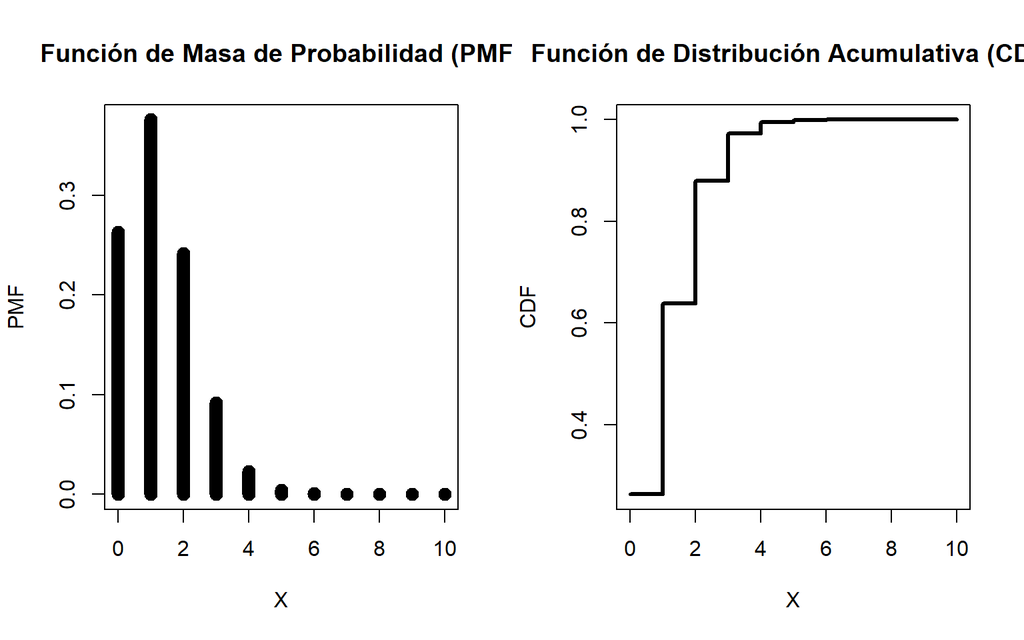

```r
library(ggplot2)
n <- 10
p <- 1/8
pmf <- dbinom(x, size = n, prob = p)
cdf <- pbinom(x, size = n, prob = p)
par(mfrow=c(1,2))
plot(x, pmf, type = "h", lwd = 10, xlab = "X", ylab = "PMF",
     main = "Función de Masa de Probabilidad (PMF)")
plot(x, cdf, type = "s", lwd = 3, xlab = "X", ylab = "CDF",
     main = "Función de Distribución Acumulativa (CDF)")
```

3. $n=10$ y $p=4/5$

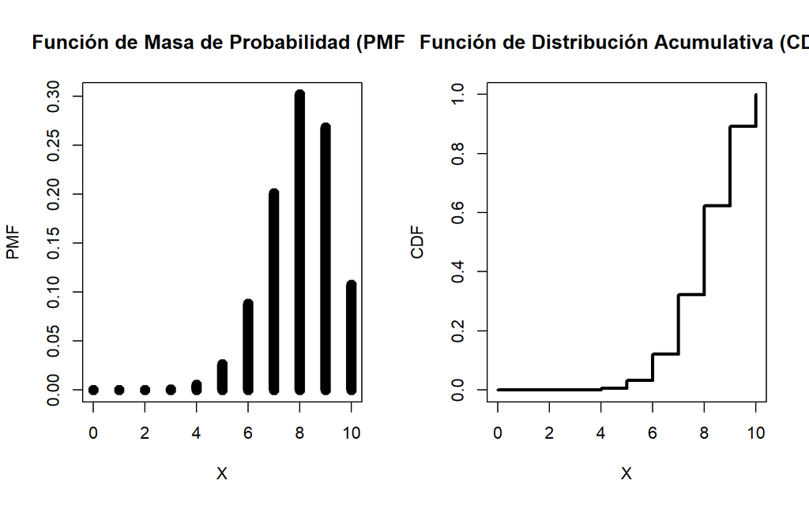

```r
library(ggplot2)
n <- 10
p <- 4/5
x <- 0:n
pmf <- dbinom(x, size = n, prob = p)
cdf <- pbinom(x, size = n, prob = p)
par(mfrow=c(1,2))
plot(x, pmf, type = "h", lwd = 10, xlab = "X", ylab = "PMF",
     main = "Función de Masa de Probabilidad (PMF)")
plot(x, cdf, type = "s", lwd = 3, xlab = "X", ylab = "CDF",
     main = "Función de Distribución Acumulativa (CDF)")
```

4. $n=10$ y $p=1/2$

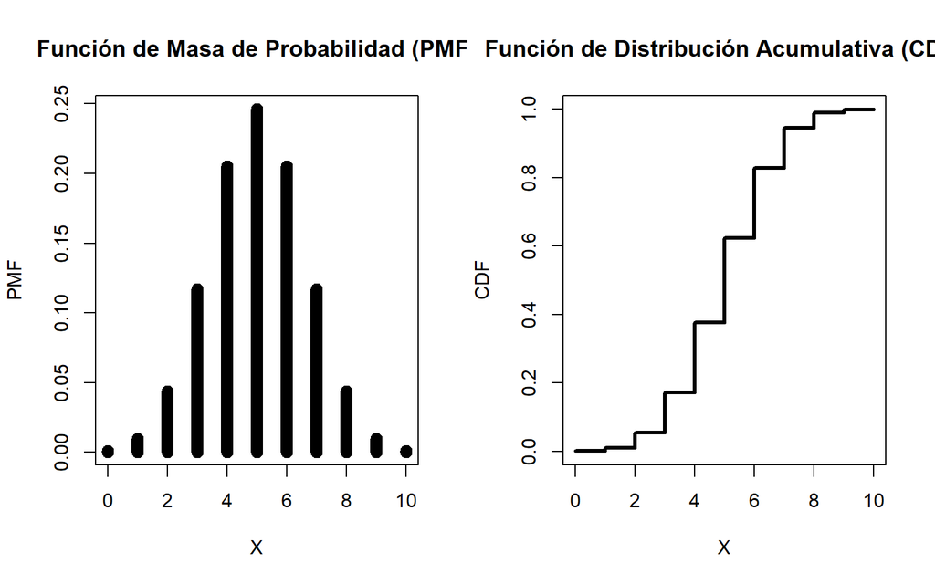

```r
library(ggplot2)
n <- 10
p <- 1/2
x <- 0:n
pmf <- dbinom(x, size = n, prob = p)
cdf <- pbinom(x, size = n, prob = p)
par(mfrow=c(1,2))
plot(x, pmf, type = "h", lwd = 10, xlab = "X", ylab = "PMF",
     main = "Función de Masa de Probabilidad (PMF)")
plot(x, cdf, type = "s", lwd = 3, xlab = "X", ylab = "CDF",
     main = "Función de Distribución Acumulativa (CDF)")
```

3. ¿Tiene algún efecto $n$ y $p$ para que la pmf sea simétrica? ¿Cuál? R= Cuando p=0.5 y n es par, la distribución binomial sigue siendo simétrica en torno a su media.
4. ¿Qué efecto tiene $p$ en la asimetría? R= representa la probabilidad de éxito en cada ensayo.

# Variables aletorias continuas

Las variables aleatorias continuas, a diferencia de las discretas, quedan totalmente definidas mediante su PDF y CDF. Existen múltiples variables aleatorias bien conocidas y que sirven para modelar diversos fenómenos. La densidad Gamma está dada por la siguiente ecuación:
$$f_X(x, \alpha, \beta) = \begin{cases}
\frac{\beta^{\alpha}}{\Gamma(\alpha)} x^{\alpha-1} \mbox{e}^{-\beta x}
& x>0\\
0 & x\le 0
\end{cases}$$
donde $\alpha>0$ y $\beta >0$.

## Actividad

1. ¿Qué efecto tiene incrementar $\alpha$? Grafique para contestar.

```r
library(pracma)
```

[figure not shown]

```r
beta <- 2
x <- seq(0.1, 10, length.out = 1000)
alphas <- c(1, 2, 3, 4)
plot(x, dgamma(x, shape = alphas[1], rate = beta), type = "l",
     xlim = c(0, 10), ylim = c(0, 0.6), col = "blue",
     xlab = "x", ylab = "Densidad de probabilidad",
     main = "Densidad Gamma para diferentes valores de α con β=2")

for (alpha in alphas[-1]) {
  lines(x, dgamma(x, shape = alpha, rate = beta), col = rainbow(length(alphas))[alpha])
}
legend("topright", legend = paste("α =", alphas), col = rainbow(length(alphas)), lty = 1, cex = 0.8)
```

2. ¿Qué efecto tiene $\beta$ en la forma de la densidad? Grafique para contestar.

[figure not shown]

```r
library(pracma)
alpha <- 2
x <- seq(0.1, 10, length.out = 1000)
betas <- c(0.5, 1, 2, 4)
plot(x, dgamma(x, shape = alpha, rate = betas[1]), type = "l",
     xlim = c(0, 10), ylim = c(0, 1), col = "yellow",
     xlab = "x", ylab = "Densidad de probabilidad",
     main = "Densidad Gamma para diferentes valores de β con α=2")

for (i in 2:length(betas)) {
  lines(x, dgamma(x, shape = alpha, rate = betas[i]), col = rainbow(length(betas))[i])
}

legend("topright", legend = paste("β =", betas), col = c("blue", rainbow(length(betas)-1)), lty = 1, cex = 0.8)
```

Otra variable aleatoria de interés es la variable aleatoria de Cauchy que está definida de la siguiente manera:

$$f_X(x) = \frac{\beta}{\pi ([x-\alpha]^2 + \beta^2)}$$
donde $\alpha \in \mathbb{R}$ y $\beta >0$. Supógamos que $\alpha = 5$.

## Actividad

1. ¿Qué efecto tiene $\beta$ en la función de densidad? Grafique para contestar.

[figure not shown]

```r
alpha <- 5
x <- seq(-20, 30, length.out = 1000)
betas <- c(0.5, 1, 2, 5)
plot(x, 1 / (pi * ((x - alpha)^2 + betas[1]^2)), type = "l",
     xlim = c(-20, 30), ylim = c(0, 0.25), col = "blue",
     xlab = "x", ylab = "Densidad de probabilidad",
     main = "Densidad de la variable aleatoria de Cauchy para diferentes valores de β con α=5")
for (beta in betas[-1]) {
  lines(x, 1 / (pi * ((x - alpha)^2 + beta^2)), col = rainbow(length(betas))[which(betas == beta)])
}
legend("topright", legend = paste("β =", betas), col = rainbow(length(betas)), lty = 1, cex = 0.8)
```

Supóngamos que tenemos la siguiente PDF:
$$f_X(x) = \begin{cases}
0 & x < a\\
\frac{2(x-a)}{(b-a)(c-a)} & a \le x < c\\
\frac{2}{b-a} & x=c\\
\frac{2(b-x)}{(b-a)(b-c)} & c < x \le b\\
0 & b < x
\end{cases}$$
donde $a < c < c$.

## Actividad

1. Grafique la densidad triangular cuando $a=0$, $b=4$, $c=2$

[figure not shown]

```r
a <- 0
b <- 4
c <- 2
f_X <- function(x) {
  if (x < a | x > b) {
    return(0)
  } else if (a <= x & x < c) {
    return(x / ((b - a) * (c - a)))
  } else if (x == c) {
    return(2 / (b - a))
  } else {
    return((b - x) / ((b - a) * (b - c)))
  }
}

x_values <- seq(-1, 5, length.out = 400)
y_values <- sapply(x_values, f_X)
plot(x_values, y_values, type = 'l', col = 'blue', lwd = 2,
     xlab = 'x', ylab = 'Densidad', main = 'Función de densidad de probabilidad triangular')
```

2. Grafique la densidad triangular cuando $a=1$, $c=2$, $b=4$

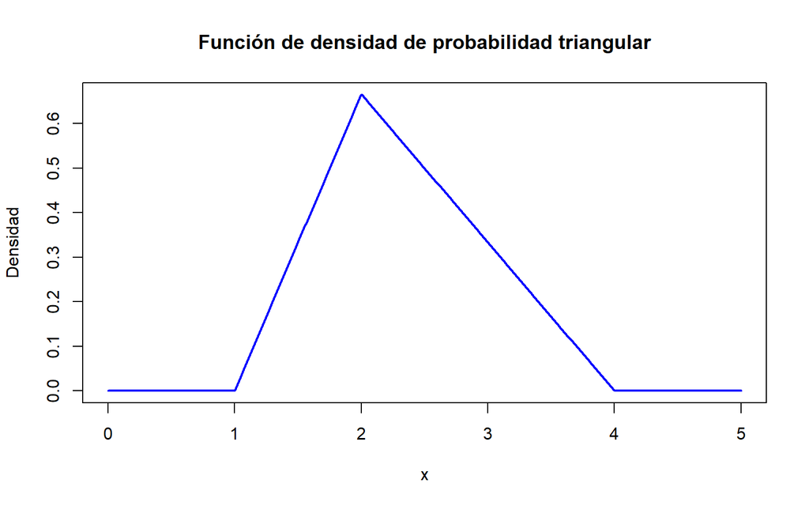

```r
a <- 1
b <- 4
c <- 2
f_X <- function(x) {
  if (x < a | x > b) {
    return(0)
  } else if (a <= x & x < c) {
    return((2 * (x - a)) / ((b - a) * (c - a)))
  } else if (x == c) {
    return(2 / (b - a))
  } else {
    return((2 * (b - x)) / ((b - a) * (b - c)))
  }
}
x_values <- seq(0, 5, length.out = 400)
y_values <- sapply(x_values, f_X)

plot(x_values, y_values, type = 'l', col = 'blue', lwd = 2,
     xlab = 'x', ylab = 'Densidad', main = 'Función de densidad de probabilidad triangular')
```

3. Grafique la densidad triangular cuando $a=-1$, $c=0$, $b=1$

[figure not shown]

```r
a <- -1
b <- 1
c <- 0
f_X <- function(x) {
  if (x < a | x > b) {
    return(0)
  } else if (a <= x & x < c) {
    return((x - a) / (b - a) / (c - a))
  } else if (x == c) {
    return(1 / (b - a))
  } else {
    return((b - x) / (b - a) / (b - c))
  }
}
x_values <- seq(-2, 2, length.out = 400)
y_values <- sapply(x_values, f_X)
plot(x_values, y_values, type = 'l', col = 'blue', lwd = 2,
     xlab = 'x', ylab = 'Densidad', main = 'Función de densidad de probabilidad triangular')
```

Tanto `R` como `python` nos permiten calcular integrales usando los comandos básicos o bién usando sistemas de cómputo algebraíco. R, por ejemplo, puede utilizar un sistema llamado `Ryacas` que permite hacer muchos cálculos de forma simbólica. Ahora, consideremos que tenemos la siguiente PDF:

$$f_X(x) = \begin{cases}
\mbox{e}^{-x} & x \ge 0\\
0 & \mbox{resto}
\end{cases}$$

## Actividad

1. $P(X>1)$
2. $P(2 < X \le 4)$
3. $P(X \le 2)$

```r
library(Ryacas)
F_X <- function(x) {
  ifelse(x >= 0, 1 - exp(-lambda * x), 0)
}
lambda <- 0.5
prob_1 <- 1 - F_X(1)
prob_2 <- F_X(4) - F_X(2)
prob_3 <- F_X(2)
print(paste("1. P(X > 1):", prob_1))
```

[output not shown]

```r
print(paste("2. P(2 < X <= 4):", prob_2))
```

[output not shown]

```r
print(paste("3. P(X <= 2):", prob_3))
```

[output not shown]

Finalmente, supongamos que tenemos la siguiente PDF:

$$f_X(x) = \frac{1}{\sqrt{2\pi}}\mbox{e}^{-\frac{(x-3)^2}{2}}$$

## Actividad

1. Graficar $f_X(3+x)$.

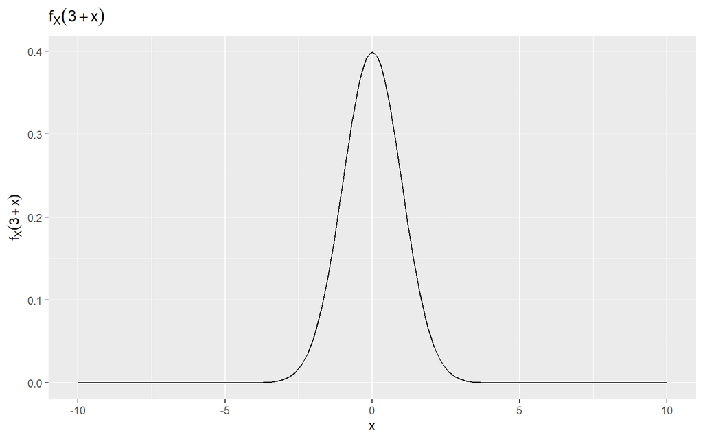

```r
library(ggplot2)
f_X <- function(x) {
  1/sqrt(2*pi) * exp(-((x-3)^2)/2)
}
x_values <- seq(-10, 10, by = 0.1)
y_values <- f_X(3 + x_values)
data <- data.frame(x = x_values, y = y_values)
ggplot(data, aes(x, y)) +
  geom_line() +
  labs(title = expression(f[X](3 + x)), x = "x", y = expression(f[X](3 + x)))
```

2. Graficar $f_X(3-x)$.

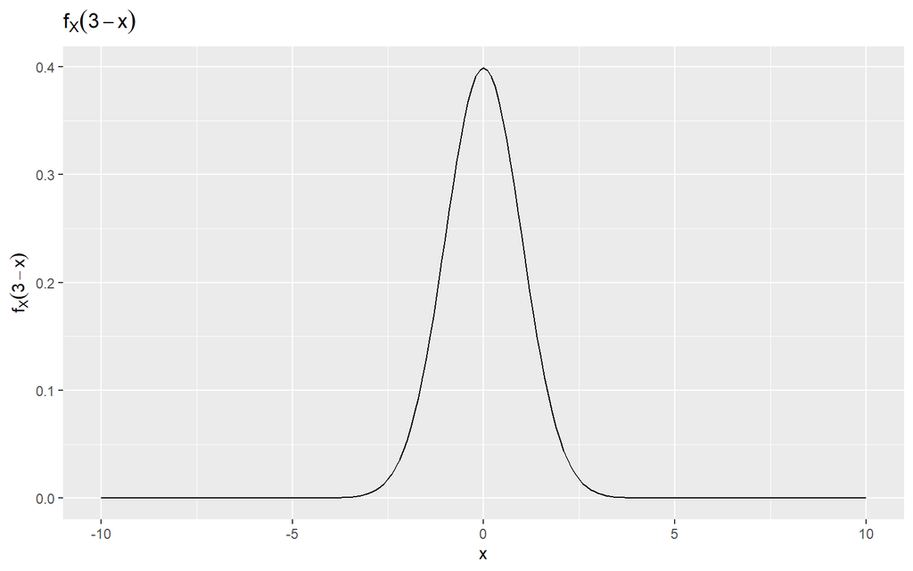

```r
library(ggplot2)
f_X <- function(x) {
  1/sqrt(2*pi) * exp(-((3-x-3)^2)/2)
}
x_values <- seq(-10, 10, by = 0.1)
y_values <- f_X(x_values)
data <- data.frame(x = x_values, y = y_values)

ggplot(data, aes(x, y)) +
  geom_line() +
  labs(title = expression(f[X](3 - x)), x = "x", y = expression(f[X](3 - x)))
```

3. Que hay en común entre estas dos gráficas y qué se puede inferir de $f_X(3+x)$ y $f_X(3-x)$ R= Ambas gráficas tienen la misma forma general, que es la forma de una distribución normal.

## Fecha de entrega: miércoles 18 de octubre de 2023 a través de Moodle.